# Chapter 15: Probability and Inference in Practice

The Practice of Statistics in the Life Sciences by Brigitte Baldi and David S. Moore

Instructor: Ali Raisolsadat

Part III: Foundations of Inference

# 15 Chapter 15

## 15.1 Inference in Practice

Chapter 14 introduced confidence intervals and hypothesis tests for a population mean under a set of simple conditions. Those procedures provide a clear introduction to the logic of inference, but using inference well requires more than knowing a formula.

The conclusions from a statistical procedure depend on several connected questions:

1. Where did the data come from?
2. Does the statistical model fit the data and the study design?
3. How much random uncertainty remains in the estimate?
4. How large is the estimated effect, and does it matter in context?
5. Was the analysis planned before the data were examined?

> **Central idea**

> Statistical methods are trustworthy when the assumptions fit the study and the conclusions remain within the limits of the design.

This chapter develops the practical judgment needed to use confidence intervals and hypothesis tests responsibly. The principles apply far beyond the one-sample $z$ procedures studied in Chapter 14.

## 15.2 Probability as the Foundation of Inference

The probability chapters and the inference chapters address different stages of the same reasoning process.

- A **probability model** starts with a proposed population or chance mechanism and describes possible outcomes.
- A **sampling distribution** describes how a statistic would vary across repeated samples drawn by the same method.
- **Statistical inference** starts with observed sample data and uses the sampling distribution to evaluate possible population values.

The direction of the reasoning changes, but the probability rules do not. Complements, disjoint-event addition, conditional probability, independence and distributional models all appear in inferential calculations.

> **Probability-to-inference connection**

> Probability asks what data could occur under a model. Inference asks whether the observed data are reasonably compatible with that model.

### 15.2.1 Parameters and Statistics

A population parameter is fixed for the population being studied, although its value is usually unknown. A sample statistic depends on the selected observations and therefore changes from sample to sample.

| Scientific quantity | Population parameter | Sample statistic |
| --- | --- | --- |
| Mean of a quantitative variable | $\mu$ | $\bar{x}$ |
| Probability of a binary outcome | $p$ | $\hat p$ |
| Event rate per unit of exposure | $\lambda$ | Observed rate or event count |

Before the sample is selected, the statistic is a random variable. After the sample has been observed, the statistic becomes a known number. Inference uses the observed value while accounting for the statistic’s pre-sampling variability.

### 15.2.2 Population Distributions and Sampling Distributions

The population distribution and the sampling distribution describe different objects.

- The **population distribution** describes individual values or outcomes.
- The **sample distribution** describes the observations in one collected sample.
- The **sampling distribution** describes a statistic across all possible samples of the same size drawn by the same process.

For example, individual body temperatures may have population standard deviation $\sigma$. The sample mean of $n$ independent temperatures has standard deviation

$$\sigma_{\bar X}=\frac{\sigma}{\sqrt{n}}$$

This smaller standard deviation is the standard error of the sample mean under the model. It measures the sample-to-sample variation relevant to inference.

### 15.2.3 Probability Rules Used in Inference

Several familiar probability rules appear directly in confidence intervals and tests.

1. **Complement rule**

   $$P(Z\ge z)=1-P(Z<z)$$

   Upper-tail probabilities often use this form.
2. **Addition of disjoint events**

   A two-sided test combines probability from two non-overlapping tails.
3. **Conditional probability**

   A $P$-value has the form

   $$P(\text{result at least as extreme as observed}\mid H_0)$$

   This probability is not the reverse conditional probability $P(H_0\mid\text{data})$.
4. **Independence**

   Standard errors and exact binomial or Poisson probabilities usually rely on observations or events behaving independently under the model.

### 15.2.4 Matching the Distribution to the Response

The response variable and study design guide the choice of a probability model.

| Response | Possible model | Parameter of interest |
| --- | --- | --- |
| Continuous measurement | Normal population model or an approximately Normal sampling distribution | Mean $\mu$ |
| Number of successes in $n$ trials | Binomial model | Success probability $p$ |
| Number of events in fixed exposure | Poisson model | Event rate $\lambda$ |

The model describes more than the shape of a distribution. A binomial model assumes a fixed number of trials, two possible outcomes, independent trials and a common success probability. A Poisson model assumes a stable event rate over the defined exposure and an event process without unexplained clustering.

### 15.2.5 Exact Probabilities and Normal Approximations

An inferential probability may be calculated directly from a discrete model or approximated using a Normal distribution.

- An **exact binomial or Poisson calculation** retains the original discrete model.
- A **Normal approximation** replaces the discrete or non-Normal sampling distribution with a Normal model when the approximation conditions are adequate.

The word *exact* refers to the calculation under the assumed probability model. If the model does not fit the study process, an exact calculation can still give a misleading conclusion.

For a binomial count, the common first-year condition for a Normal approximation is

$$np\ge10
\qquad\text{and}\qquad
n(1-p)\ge10$$

For a sample mean, the population shape and the sample size determine whether the Central Limit Theorem provides an adequate approximation.

### 15.2.6 The One-Sample $z$ Procedures

Chapter 14 considered inference about a population mean $\mu$ under three simple conditions:

- The observations came from a simple random sample
- The population distribution was Normal, or the sampling distribution of $\bar{x}$ was approximately Normal
- The population standard deviation $\sigma$ was known

Under these conditions, the confidence interval for $\mu$ is

$$\bar{x}
\pm
z^*\frac{\sigma}{\sqrt{n}}$$

The test statistic for

$$H_0:\mu=\mu_0$$

is

$$z
=
\frac{\bar{x}-\mu_0}{\sigma/\sqrt{n}}$$

These are called **$z$ procedures** because they use the Standard Normal distribution.

Knowing the population standard deviation is unusual in real applications. Chapter 17 replaces $\sigma$ with the sample standard deviation $s$ and introduces the $t$ procedures. The practical questions about study design, model conditions and interpretation remain the same.

## 15.3 Conditions for Inference in Practice

Every inferential procedure has conditions that connect its mathematical model to the study. A calculation can be numerically correct and still lead to an unreliable conclusion when those conditions do not fit the data.

Two broad questions guide the assessment:

1. **Where did the data come from?**
2. **What is the shape of the population or sampling distribution?**

The first question concerns study design. The second concerns the probability model used by the procedure.

### 15.3.1 Where the Data Come From

Statistical inference uses probability to describe how a statistic would vary over repeated samples or treatment assignments. This reasoning has a clear foundation when chance enters the study design.

Two forms of randomization play different roles.

| Design feature | How chance is used | Main conclusion supported |
| --- | --- | --- |
| Random sampling | Individuals are selected from a population by chance | Generalization from the sample to the sampled population |
| Random assignment | Experimental units are assigned to treatments by chance | Stronger evidence for a causal treatment effect |

A study can use one, both or neither form of randomization.

- A random sample without random assignment may support population generalization but not a causal conclusion
- A randomized experiment using volunteers may support a causal comparison for the participants but may not represent a broader population
- A convenience sample in an observational study generally supports neither broad generalization nor a strong causal claim

The conclusion should match the design actually used.

### 15.3.2 Acting as Though the Data Were Random

Researchers sometimes apply standard inferential procedures to data that did not come from a true probability sample or randomized experiment. In that situation, the numerical calculation treats the data as though the probability model applies.

The resulting conclusion depends on subject-matter reasoning:

- Are the sampled individuals plausibly similar to the intended population for the variable being studied?
- Could the recruitment method systematically exclude important groups?
- Could the individuals who chose to participate differ from those who did not?
- Could the measurement setting affect the recorded values?

There is no formula that repairs a biased sampling process. When random selection is absent, uncertainty extends beyond the reported standard error.

### 15.3.3 Independence of Observations

Many introductory formulas assume that the observations are independent. Independence means that learning one observation does not determine the value of another observation under the model.

Dependence can arise when

- Several measurements come from the same individual
- Animals come from the same litter or enclosure
- Patients receive care in the same clinic
- Measurements come from nearby locations or adjacent times
- Participants influence one another’s responses

When a simple random sample is drawn without replacement from a finite population, the observations are technically dependent. The dependence is usually small enough to ignore when the sample represents no more than $10\%$ of the population:

$$n\le0.10N$$

This guideline is often called the **10% condition**. It does not address clustering or repeated measurements. Those forms of dependence require a method that represents the group or repeated-measure structure.

### 15.3.4 Problems That Can Arise After a Good Design

Even a well-designed sample or experiment can encounter difficulties.

**Nonresponse** occurs when selected individuals do not provide data. Nonresponse creates bias when the people who respond differ systematically from those who do not respond.

**Attrition** occurs when participants leave a study before it ends. If departure is related to treatment, health or the outcome being studied, the remaining observations may no longer represent the original groups.

**Measurement error** occurs when the recorded value differs from the quantity the study intended to measure. Poor calibration, inconsistent procedures and inaccurate self-reports can introduce error.

**Protocol deviations** occur when participants do not follow their assigned treatment or researchers do not apply the planned procedure consistently.

These problems are not automatically represented in a standard confidence interval or P-value.

### 15.3.5 Complex Sampling Designs

A simple random sample gives every possible sample of size $n$ the same chance of selection. Large surveys often use more complicated designs, such as

- Stratified sampling
- Cluster sampling
- Multistage sampling
- Unequal selection probabilities

These designs can be efficient and scientifically appropriate, but the analysis must account for how the sample was selected. Treating a complex design as an SRS can produce incorrect standard errors and confidence intervals.

The design and the analysis should be planned together.

### 15.3.6 The Population Model

Parametric inference begins with a probability model for the population. For inference about a mean, the model identifies the population mean $\mu$ as the unknown parameter.

The one-sample $z$ procedures use the distribution of the sample mean. The relevant condition is therefore the shape of the **sampling distribution of $\bar{x}$**, not necessarily the exact shape of the individual observations.

If the population is Normal, then

$$\bar{X}
\sim
N\left(
\mu,
\frac{\sigma}{\sqrt{n}}
\right)$$

for every sample size $n$.

If the population is not Normal, the Central Limit Theorem often makes the sampling distribution of $\bar{x}$ approximately Normal when the sample size is sufficiently large.

### 15.3.7 Sample Size and Normality

The sample size needed for a reasonable Normal approximation depends on the population shape.

- A nearly symmetric population with light tails may require only a moderate sample
- A strongly skewed population may require a larger sample
- A population with heavy tails or extreme outliers may require a very large sample or a different method

There is no universal rule that makes $n=30$ sufficient for every population.

When the population distribution is unknown, previous research and graphs of the sample data provide useful evidence. A dotplot, histogram or Normal quantile plot can reveal strong skewness, gaps and unusual observations.

### 15.3.8 Small Samples and Outliers

Small samples contain limited information about population shape. A sample of only a few observations may appear roughly symmetric even when the population is not.

Outliers deserve particular attention because the sample mean and sample standard deviation are not resistant. One extreme observation can

- Shift the value of $\bar{x}$
- Increase the value of $s$
- Change a confidence interval
- Alter the test statistic and P-value

Before removing an observation, researchers should determine whether it reflects a data-entry error, measurement problem or valid but unusual case. An observation should not be excluded only because its removal makes the analysis more favourable.

### 15.3.9 A Practical Conditions Checklist

Before using an inferential procedure, ask:

1. What population or treatment comparison does the study address?
2. How were individuals selected?
3. Was treatment assigned randomly?
4. Are the observations sufficiently independent?
5. Does the population or sampling-distribution model fit the data and sample size?
6. Are outliers, missing values or measurement problems present?
7. Does the procedure account for the actual sampling or experimental design?

The answers determine whether the standard error, confidence interval and P-value have a defensible interpretation.

### 15.3.10 Example 15.1: The Neurobiologist and the Sociologist

Two researchers recruit students from introductory courses at one university.

**Neurobiology study:** A neurobiologist studies how people with normal vision respond to an optical illusion. Basic visual-processing mechanisms may be similar across many groups. Subject-matter knowledge may therefore support a cautious interpretation beyond the specific class, even though the students are not an actual random sample of all people with normal vision.

**Sociology study:** A sociologist studies attitudes toward the use of human participants in scientific research. Age, education, field of study, family background and campus culture may all affect these attitudes. Students in one sociology class are unlikely to represent all adults or even all university students.

The sampling method is similar in the two studies, but the plausibility of broader generalization differs because the variables and scientific questions differ.

> **Main lesson**

> Whether a convenience sample can support a broader conclusion depends partly on how the selection process could relate to the variable being studied.

### 15.3.11 Additional Study-Design Examples

Three studies from Chapter 14 illustrate different relationships between the sample and the intended population.

| Study | Data source | Assessment |
| --- | --- | --- |
| Heights in NHANES | A complex multistage probability sample | The sample is broadly representative, but a formal analysis should account for the complex design |
| IQ scores in a school district | A random sample of seventh-grade girls in the district | The design supports inference to the stated district population |
| Blood phosphorus measurements | Random medical records from one laboratory in Ohio | The sample may represent a narrow laboratory-related population but not all adults aged $75$ to $79$ |

The phosphorus study has two important limitations. Patients whose blood was tested at one laboratory may differ from the broader population, and laboratory procedures can affect recorded measurements. These limitations restrict generalization even though the records were randomly selected from that laboratory.

The population named in the conclusion should match the population the sampling process can reasonably represent.

## 15.4 How Confidence Intervals Behave

Many confidence intervals have the form

$$\text{estimate}
\pm
\text{margin of error}$$

The margin of error combines a critical value with the standard error of the estimate:

$$\text{margin of error}
=
\text{critical value}
\times
\text{standard error}$$

For the one-sample $z$ interval for a population mean,

$$m
=
z^*\frac{\sigma}{\sqrt{n}}$$

Three quantities determine the margin of error:

- The confidence level through the critical value $z^*$
- The population variability through $\sigma$
- The sample size through $n$

### 15.4.1 From the Sampling Distribution to a Confidence Interval

The interval formula follows from a probability statement about the sample mean. Under the one-sample $z$ model,

$$Z
=
\frac{\bar X-\mu}{\sigma/\sqrt{n}}
\sim N(0,1)$$

The central $95\%$ of the Standard Normal distribution lies between approximately $-1.96$ and $1.96$:

$$P\left(
-1.96
\le
\frac{\bar X-\mu}{\sigma/\sqrt{n}}
\le
1.96
\right)
=0.95$$

Rearranging the inequalities places $\mu$ in the centre:

$$P\left(
\bar X-1.96\frac{\sigma}{\sqrt{n}}
\le
\mu
\le
\bar X+1.96\frac{\sigma}{\sqrt{n}}
\right)
=0.95$$

Before sampling, the endpoints are random because they depend on $\bar X$. The parameter $\mu$ is fixed.

### 15.4.2 Long-Run Coverage

A $95\%$ confidence procedure has a long-run coverage rate of $95\%$ under the stated model. If the same sampling process were repeated many times, approximately $95\%$ of the resulting intervals would contain the true parameter and approximately $5\%$ would miss it.

After one sample has been collected, the calculated interval is fixed. The usual frequentist interpretation refers to the reliability of the procedure rather than a probability assigned to the fixed parameter.

> **Suitable interpretation**

> We are $95\%$ confident that the population parameter lies between the reported endpoints because the method captures the true parameter in approximately $95\%$ of repeated samples under the model conditions.

### 15.4.3 Confidence and Precision

A confidence interval ideally has both a high confidence level and a small margin of error.

The confidence level describes the long-run success rate of the interval-building procedure. A smaller margin of error describes a more precise estimate. With the same data, these goals compete.

| Confidence level | Critical value $z^*$ | Effect on interval width |
| --- | --- | --- |
| $90\%$ | $1.645$ | Narrower |
| $95\%$ | $1.960$ | Intermediate |
| $99\%$ | $2.576$ | Wider |

A higher confidence level includes a larger central area under the Standard Normal curve. The larger value of $z^*$ increases the margin of error.

Lowering the confidence level produces a narrower interval, but it also reduces the long-run coverage rate. It does not create additional information in the data.

### 15.4.4 Population Variability

The population standard deviation $\sigma$ measures the variability among individual values.

From

$$m
=
z^*\frac{\sigma}{\sqrt{n}}$$

the margin of error is directly proportional to $\sigma$. If all other quantities remain fixed, doubling $\sigma$ doubles the margin of error.

Natural biological variation often cannot be reduced. Measurement-related variation may sometimes be reduced through

- More precise instruments
- Standardized measurement procedures
- Better training and quality control
- Repeated measurements when scientifically appropriate

The value of $\sigma$ used for planning should describe the population and measurement process relevant to the study.

### 15.4.5 Sample Size and Precision

For fixed values of $z^*$ and $\sigma$,

$$m
\propto
\frac{1}{\sqrt{n}}$$

Larger samples produce more precise estimates, but precision improves according to a square-root relationship.

| Change in sample size | Change in standard error | Change in margin of error |
| --- | --- | --- |
| $n$ becomes $4n$ | Divided by $2$ | Divided by $2$ |
| $n$ becomes $9n$ | Divided by $3$ | Divided by $3$ |
| $n$ becomes $100n$ | Divided by $10$ | Divided by $10$ |

Doubling the sample size multiplies the margin of error by

$$\frac{1}{\sqrt{2}}
\approx
0.707$$

Therefore, doubling the sample size reduces the margin of error by approximately $29.3\%$, not by $50\%$.

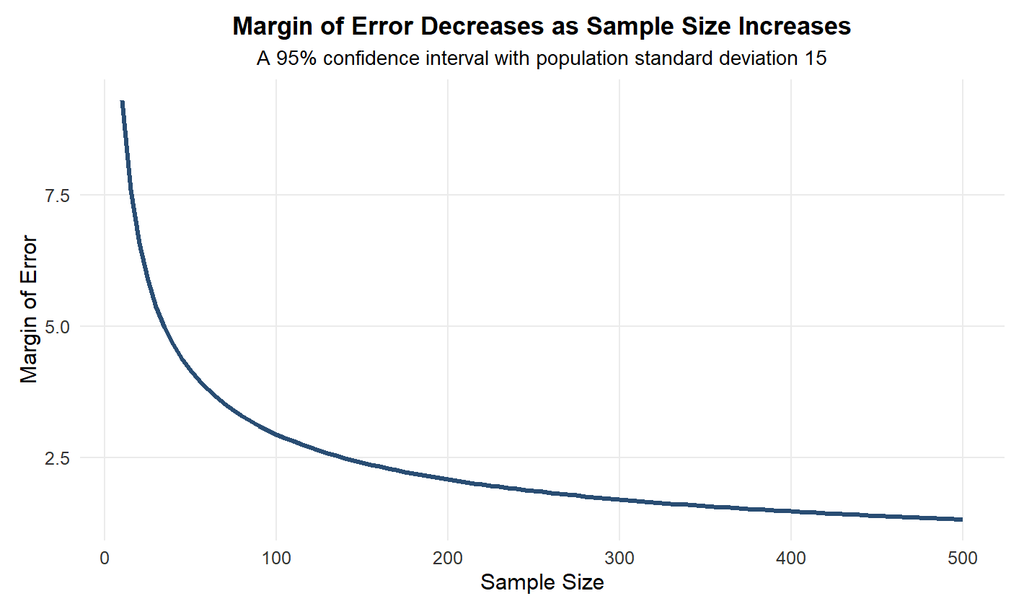

The curve becomes flatter as $n$ increases. When a study already has a large sample, obtaining the same absolute reduction in margin of error may require many additional observations.

### 15.4.6 Example 15.4: Confidence Level and Margin of Error

The IQ study has

$$\bar{x}=105.84
\qquad
\sigma=15
\qquad
n=31$$

The standard error is

$$\operatorname{SE}(\bar{x})
=
\frac{15}{\sqrt{31}}
\approx
2.694$$

For a $95\%$ confidence level,

$$m_{95}
=
1.960\left(\frac{15}{\sqrt{31}}\right)
\approx
5.28$$

The interval is

$$105.84\pm5.28$$

$$\boxed{(100.56,\ 111.12)}$$

For a $90\%$ confidence level,

$$m_{90}
=
1.645\left(\frac{15}{\sqrt{31}}\right)
\approx
4.43$$

The interval is

$$\boxed{(101.41,\ 110.27)}$$

For a $99\%$ confidence level,

$$m_{99}
=
2.576\left(\frac{15}{\sqrt{31}}\right)
\approx
6.94$$

The interval is

$$\boxed{(98.90,\ 112.78)}$$

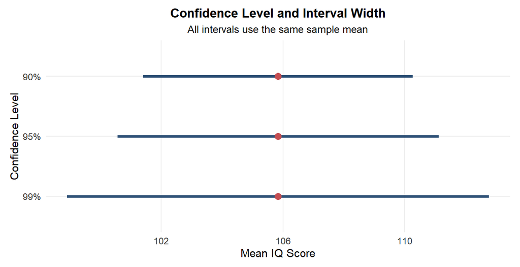

All three intervals are centred at the same sample mean. The higher confidence levels produce wider intervals.

The calculations can be checked with short R commands.

```r
x_bar <- 105.84
sigma <- 15
n <- 31

confidence_levels <- c(0.90, 0.95, 0.99)
z_star <- qnorm((1 + confidence_levels) / 2)
margin_error <- z_star * sigma / sqrt(n)

data.frame(
  confidence_level = confidence_levels,
  z_star = round(z_star, 3),
  margin_error = round(margin_error, 2),
  lower = round(x_bar - margin_error, 2),
  upper = round(x_bar + margin_error, 2)
)
```

```
##   confidence_level z_star margin_error  lower  upper
## 1             0.90  1.645         4.43 101.41 110.27
## 2             0.95  1.960         5.28 100.56 111.12
## 3             0.99  2.576         6.94  98.90 112.78
```

### 15.4.7 Example 15.4 (continued): Doubling the Sample Size

The original $95\%$ margin of error is

$$m_{31}
=
1.960\frac{15}{\sqrt{31}}
\approx
5.28$$

If the sample size increases from $31$ to $62$, then

$$m_{62}
=
1.960\frac{15}{\sqrt{62}}
\approx
3.73$$

The ratio of the margins is

$$\frac{m_{62}}{m_{31}}
=
\sqrt{\frac{31}{62}}
=
\frac{1}{\sqrt{2}}
\approx
0.707$$

Doubling the sample size does not halve the margin of error. A fourfold increase from $31$ to $124$ would be required to reduce the original margin by one-half.

A new sample would also usually produce a different sample mean. Increasing $n$ determines how the margin changes, but it does not guarantee that the interval will have the same centre.

```r
margin_31 <- qnorm(0.975) * 15 / sqrt(31)
margin_62 <- qnorm(0.975) * 15 / sqrt(62)
margin_124 <- qnorm(0.975) * 15 / sqrt(124)

round(
  c(
    n_31 = margin_31,
    n_62 = margin_62,
    n_124 = margin_124
  ),
  3
)
```

```
##  n_31  n_62 n_124
## 5.280 3.734 2.640
```

### 15.4.8 What the Margin of Error Measures

The margin of error describes uncertainty caused by random sampling under the assumed model. It measures how far the statistic may fall from the parameter because different random samples contain different observations.

> **Covered by the margin of error**

> Random sample-to-sample variation generated by the stated sampling process

This limitation follows from the sampling distribution. A sampling distribution describes the variation of a statistic across repeated random samples. It does not describe every way in which a study can go wrong.

### 15.4.9 What the Margin of Error Does Not Measure

The usual margin of error does not include uncertainty or bias caused by

- Undercoverage
- Voluntary response
- Nonresponse
- Leading or ambiguous questions
- Inaccurate self-reports
- Systematic measurement error
- Confounding
- Attrition related to treatment or outcome
- A mismatch between the statistical procedure and the study design

These problems can be more serious than random sampling error.

For example, a public-opinion poll may report a small sampling margin of error even when few selected individuals respond. The calculation measures random variation under the assumed sampling model. It does not show that respondents and nonrespondents have similar opinions.

Similarly, a clinical trial may produce a precise interval for the participants who remain in the study. If participants with severe side effects leave at a higher rate, the usual interval does not measure the bias created by that attrition.

> **Important caution**

> A narrow confidence interval indicates high precision under the model. It does not guarantee that the estimate is accurate or free from bias.

## 15.5 How Hypothesis Tests Behave

Hypothesis tests evaluate evidence about a population parameter under a specified model. The procedure begins by assuming that the null hypothesis is true and then asks how unusual the observed result would be under that assumption.

For a one-sample $z$ test of a population mean,

$$z
=
\frac{\bar{x}-\mu_0}{\sigma/\sqrt{n}}$$

The P-value is the probability, calculated under the null hypothesis and model conditions, of obtaining a test statistic at least as extreme as the observed statistic in the direction specified by the alternative hypothesis.

### 15.5.1 From the Null Model to a P-Value

The test statistic locates the observed result within the null sampling distribution.

For the one-sample $z$ statistic,

$$z
=
\frac{\bar{x}-\mu_0}{\sigma/\sqrt{n}}$$

the numerator is the observed difference from the null value and the denominator is the standard error expected from random sampling. A value such as $z=2.4$ means that the observed sample mean is $2.4$ standard errors above the null mean.

The alternative hypothesis determines which outcomes count as at least as extreme:

- An upper-tail alternative uses probability to the right of $z_{\text{obs}}$
- A lower-tail alternative uses probability to the left of $z_{\text{obs}}$
- A two-sided alternative combines equally extreme outcomes in both tails

Thus, the $P$-value has the conditional form

$$P(\text{test statistic at least as extreme as observed}\mid H_0)$$

It does not have the reverse form $P(H_0\mid\text{observed statistic})$.

### 15.5.2 Evidence Is Continuous

Smaller P-values indicate that the observed data are less compatible with the null model. Evidence does not change abruptly at a conventional threshold.

For example, the values

$$P=0.048
\qquad\text{and}\qquad
P=0.052$$

represent nearly the same strength of evidence, even though a fixed rule with $\alpha=0.05$ places them on opposite sides of the decision threshold.

By contrast,

$$P=0.004$$

provides substantially stronger evidence against $H_0$ than

$$P=0.04$$

Reporting the exact P-value communicates more information than reporting only whether a result is statistically significant.

### 15.5.3 How Small Must a P-Value Be?

The strength of evidence required for a decision depends partly on the setting.

**Plausibility of the null hypothesis:** A well-established claim may require stronger evidence before researchers revise it.

**Consequences of rejection:** A decision involving serious health risks, high costs or an irreversible policy change may require stronger evidence than a preliminary decision to continue investigating a question.

**Quality of the study:** A small P-value from biased or poorly measured data does not provide reliable evidence about the intended population question.

Conventional significance levels such as $0.05$ and $0.01$ can support consistent decision rules, but $\alpha=0.05$ should not be treated as a universal boundary between meaningful and meaningless results.

### 15.5.4 Type I and Type II Errors

A hypothesis-test decision can be correct or incorrect.

| Decision | $H_0$ is true | A specified alternative is true |
| --- | --- | --- |
| Fail to reject $H_0$ | Correct decision | Type II error |
| Reject $H_0$ | Type I error | Correct decision |

A **Type I error** occurs when the test rejects a true null hypothesis.

$$P(\text{Type I error})
=
\alpha$$

A **Type II error** occurs when the test fails to reject $H_0$ even though a specified alternative is true. Its probability is denoted by $\beta$.

$$P(\text{Type II error at a specified alternative})
=
\beta$$

The relative seriousness of these errors depends on context. For example, approving an ineffective treatment and failing to identify an effective treatment have different consequences.

### 15.5.5 The Alternative Hypothesis Determines the Tail

The alternative hypothesis determines which outcomes count as evidence against $H_0$.

| Alternative hypothesis | Relevant area for the P-value |
| --- | --- |
| $H_a:\mu>\mu_0$ | Right tail |
| $H_a:\mu<\mu_0$ | Left tail |
| $H_a:\mu\ne\mu_0$ | Both tails |

For a symmetric sampling distribution, a one-sided P-value is often one-half of the corresponding two-sided P-value when the observed effect is in the specified direction.

The direction must be justified by the scientific question and existing knowledge before the data are examined. Choosing a one-sided alternative after seeing the sample result makes the evidence appear stronger than the planned analysis permits.

### 15.5.6 Example 15.2: Exact Binomial Inference for a Treatment Response

A veterinary study evaluates whether a treatment reaches a proposed response probability of $0.80$. Among $60$ independently treated dogs, $41$ show the response defined in the study protocol.

Let $X$ be the number of dogs that respond. The hypotheses are

$$H_0:p=0.80$$

$$H_a:p<0.80$$

Under the null hypothesis,

$$X\sim\operatorname{Bin}(60,0.80)$$

The P-value is a conditional probability. The notation

$$P(X\le41\mid H_0)$$

means that the probability is calculated while treating the null model as true. In this example,

$$P(X\le41\mid H_0)
=
P(X\le41\mid p=0.80)$$

Because the alternative concerns a lower response probability, the relevant outcomes are $41$ or fewer responses:

$$P(X=x\mid H_0)
=
\binom{60}{x}(0.80)^x(0.20)^{60-x}$$

$$P(X\le41\mid p=0.80)
=
\sum_{x=0}^{41}
\binom{60}{x}(0.80)^x(0.20)^{60-x}$$

$$P(X\le41\mid p=0.80)
\approx
0.0221$$

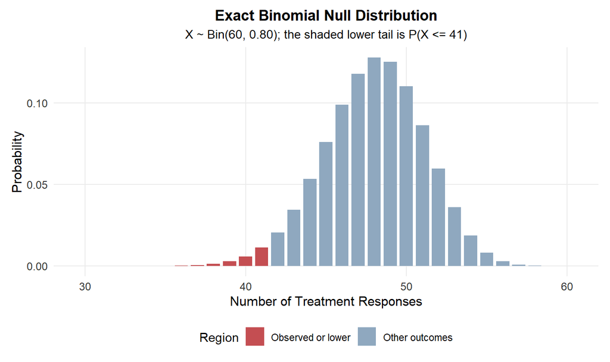

If the null model were correct, a response count of $41$ or fewer would occur in approximately $2.21\%$ of comparable studies. At $\alpha=0.05$, the result is statistically significant and provides evidence that the response probability is below $0.80$.

The conclusion depends on the binomial assumptions:

- Each dog has a response or no response according to the stated definition
- The study includes a fixed number of $60$ trials
- Outcomes are sufficiently independent
- The same response probability is reasonable for the population represented by the study

The exact calculation can be obtained in R with one line.

```r
n_dogs <- 60
p_null <- 0.80
x_observed <- 41

p_value <- pbinom(
  q = x_observed,
  size = n_dogs,
  prob = p_null
)

p_value
```

```
## [1] 0.02206845
```

```r
# [1] 0.02206845
```

The argument `q = 41` includes every possible count from $0$ through $41$, which matches the lower-tail event in the summation.

The Normal approximation conditions are satisfied because

$$np=60(0.80)=48$$

and

$$n(1-p)=60(0.20)=12$$

With a continuity correction, the approximate lower-tail probability is

$$P(X\le41)
\approx
P(Y\le41.5)$$

where

$$Y\sim N\left(48,\sqrt{60(0.80)(0.20)}\right)$$

The exact binomial calculation remains preferable when it is readily available.

### 15.5.7 Example 15.3: Exact Poisson Inference for a Disease Count

A wildlife-health program historically records an average of $12$ confirmed cases of a disease per month. During one month, the program records $20$ cases. Researchers want to determine whether this count is unusually high under the historical-rate model.

Let $X$ be the number of confirmed cases in one month. The null model is

$$H_0:\lambda=12$$

$$H_a:\lambda>12$$

$$X\sim\operatorname{Pois}(12)$$

The conditional notation

$$P(X\ge20\mid H_0)
=
P(X\ge20\mid\lambda=12)$$

means that the tail probability is calculated under the historical mean of $12$ cases per month. For any single count $x$,

$$P(X=x\mid H_0)
=
e^{-12}\frac{12^x}{x!}$$

The upper-tail probability is

$$P(X\ge20\mid\lambda=12)
=
1-P(X\le19\mid\lambda=12)$$

$$=
1-
\sum_{x=0}^{19}
e^{-12}\frac{12^x}{x!}$$

$$P(X\ge20\mid\lambda=12)
\approx
0.0213$$

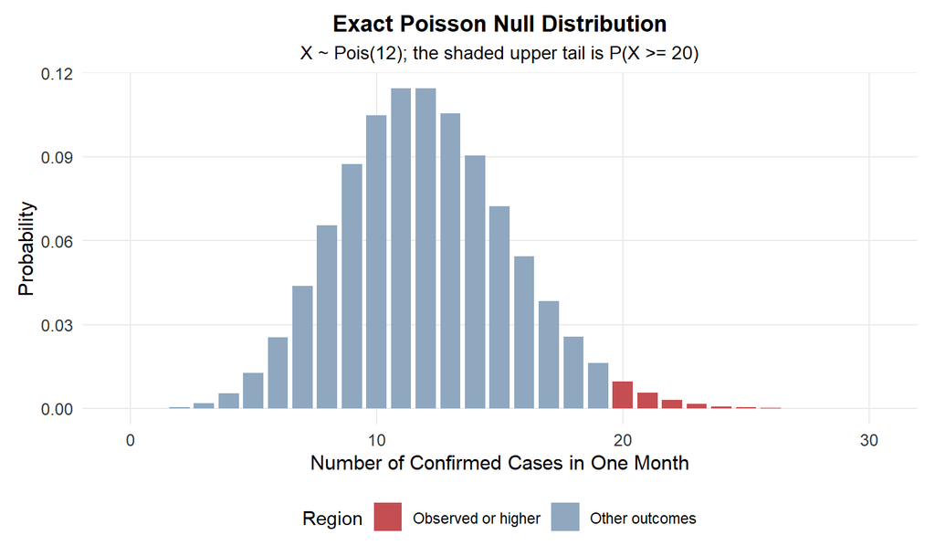

Under the stable-rate model, a monthly count of $20$ or more would occur in approximately $2.13\%$ of months. This result provides evidence against the proposed rate of $12$ cases per month.

The calculation uses the complement rule because R can calculate the cumulative probability through $19$:

```r
lambda_null <- 12
x_observed <- 20

p_value <- ppois(
  q = x_observed - 1,
  lambda = lambda_null,
  lower.tail = FALSE
)

p_value
```

```
## [1] 0.02127977
```

```r
# [1] 0.02127977
```

Because `lower.tail = FALSE`, R calculates $P(X>19)$. For an integer-valued count, $X>19$ is the same event as $X\ge20$. An equivalent calculation is `1 - ppois(19, lambda = 12)`.

Before concluding that the underlying disease rate increased, researchers should consider whether the Poisson assumptions and exposure remained reasonable. Possible concerns include

- Seasonal changes in disease occurrence
- Increased testing or surveillance effort
- Clustering within a location or animal group
- A change in the size of the population at risk

The small tail probability shows tension with the stated Poisson model. It does not identify which assumption or rate changed.

### 15.5.8 Statistical Significance Depends on Sample Size

The $z$ statistic can be viewed as

$$z
=
\frac{\text{size of the observed effect}}
{\text{size of chance variation}}$$

For a one-sample mean,

$$z
=
\frac{\bar{x}-\mu_0}
{\sigma/\sqrt{n}}$$

The P-value therefore depends on three quantities:

1. The observed effect $\bar{x}-\mu_0$
2. The population variability $\sigma$
3. The sample size $n$

As $n$ increases, the standard error decreases. A very large sample can produce a large test statistic for a small effect. A small sample or a highly variable population may produce weak statistical evidence even when the observed effect is fairly large.

Failing to reject $H_0$ does not show that the effect is exactly zero. The study may have had insufficient information to detect an effect.

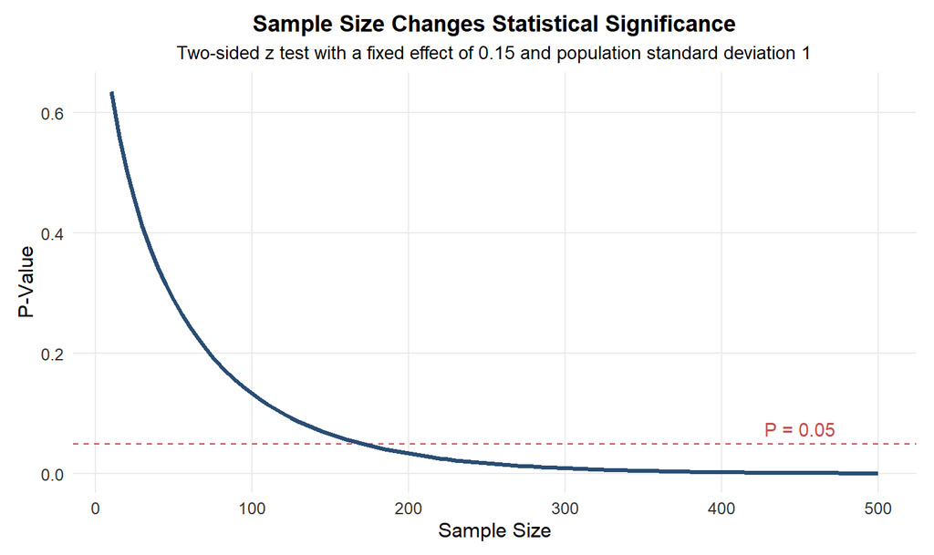

The figure holds the observed effect and population standard deviation fixed while increasing the sample size. The decreasing curve shows that the same small effect can produce a much smaller P-value when it is estimated with greater precision. This is why an effect estimate and confidence interval should be considered together with statistical significance.

### 15.5.9 Statistical Significance and Practical Importance

Statistical significance and practical importance address different questions.

| Question | Relevant information |
| --- | --- |
| Are the data difficult to explain under $H_0$? | P-value and model conditions |
| How large might the effect be? | Estimate and confidence interval |
| Is the effect important? | Scientific, clinical or policy context |

A P-value does not report the size of an effect. A confidence interval is more informative about the plausible magnitude, but the interval still requires context.

A difference of $0.2$ units may be important for one outcome and negligible for another. Subject-matter knowledge is necessary to identify a meaningful threshold.

### 15.5.10 Example 15.5: Facebook’s Large-Scale Experiment

Facebook conducted a randomized experiment involving $689{,}003$ users. For one week, the platform reduced the amount of positive or negative emotional content from friends that appeared in selected users’ News Feeds. The users’ subsequent posts were then examined.

The reported tests included

$$z=-4.78
\qquad
P<0.001$$

and

$$z=-7.219
\qquad
P<0.001$$

These results provide strong statistical evidence that the manipulation changed the language used in later posts.

The estimated effect was approximately one fewer emotional word for every $1000$ words written during the following week.

The very large sample made the study sensitive to this small average effect. The small P-values show that the observed changes would be unusual under a zero-effect model. They do not show that the changes were large.

### 15.5.11 Example 15.5 (continued): Is the Effect Important?

The Facebook experiment raises questions that cannot be answered by the P-value alone.

1. Does using fewer emotional words indicate a meaningful change in emotion?
2. Could users simply repeat words that recently appeared in their feeds?
3. Did the experimental manipulation resemble normal use of the platform?
4. Could a very small individual effect become important when applied across a very large population?

The response variable measured language in posts, not emotional state directly. The interpretation therefore depends on the validity of that measurement.

The effect was small for an individual user, but a small effect may accumulate across many users and repeated exposures. Determining practical importance requires the effect estimate, confidence interval, measurement quality and consequences in the setting.

> **Main lesson**

> Statistical significance answers a narrow probability question. It does not determine whether an effect is meaningful.

### 15.5.12 What a P-Value Is Not

A P-value is frequently misinterpreted. It is not

- The probability that $H_0$ is true
- The probability that $H_a$ is true
- The probability that the observed result occurred only by chance
- The probability that the researchers made a Type I error after seeing the data
- A measure of effect size or practical importance

A large P-value means that the observed data remain reasonably compatible with the null model. It does not prove that $H_0$ is true because other parameter values may also be compatible with the data.

A small P-value can arise because the null value is wrong, because the model assumptions are wrong or because both are wrong. The design and conditions must therefore be assessed before the P-value is interpreted.

### 15.5.13 Multiple Analyses

Every test conducted at level $\alpha$ has a probability $\alpha$ of rejecting $H_0$ when the null hypothesis is true.

If $20$ independent tests are conducted at $\alpha=0.05$ and all $20$ null hypotheses are true, the probability that none is rejected is

$$(1-0.05)^{20}
=
0.95^{20}
\approx
0.358$$

Therefore, the probability of at least one rejection is

$$1-0.95^{20}
\approx
0.642$$

This calculation does not mean that every set of $20$ analyses has exactly the same behaviour. The tests may not be independent. It does illustrate why repeatedly searching for a small P-value increases the chance of a false positive.

```r
number_of_tests <- 20
alpha <- 0.05

probability_at_least_one <- 1 - (1 - alpha)^number_of_tests
round(probability_at_least_one, 3)
```

```
## [1] 0.642
```

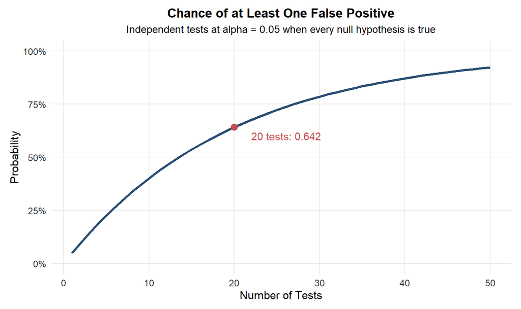

Under the illustrative independence assumption, the probability of at least one false positive increases quickly as the number of tests grows. With $20$ tests at level $alpha=0.05$, the probability is approximately $0.642$. Dependence among tests changes the exact probability, but not the broader warning that an unreported search across many analyses can inflate false-positive risk.

**P-hacking** or **data dredging** occurs when researchers try many outcomes, subgroups or models and emphasize only analyses that produce small P-values.

**Selective reporting** occurs when nonsignificant findings are omitted.

**Publication bias** occurs when studies with significant results are more likely to become publicly available than studies with nonsignificant results.

These practices distort the published evidence.

### 15.5.14 Replication and Transparency

Replication repeats a study with new observations and an independently specified analysis. A successful replication reduces the chance that the original finding depended on an unusual sample, an unnoticed design problem or a flexible analysis decision.

Useful scientific practices include

- Stating the research question and analysis plan before examining results
- Reporting all planned outcomes and analyses
- Reporting estimates and uncertainty in addition to P-values
- Distinguishing exploratory analyses from confirmatory analyses
- Sharing enough methodological information for others to evaluate or reproduce the work

One study rarely settles an important scientific question. Evidence becomes stronger when results remain consistent across well-designed studies using different samples and settings.

## 15.6 Planning Studies: Selecting a Sample Size

Study planning should include the intended statistical analysis. The sample size affects both the precision of a confidence interval and the ability of a hypothesis test to detect an effect.

Larger samples provide more information, but collecting observations may require time, money, specialized equipment or participant risk. A useful design balances statistical performance with practical and ethical constraints.

### 15.6.1 Sample Size for a Desired Margin of Error

For a one-sample $z$ confidence interval,

$$m
=
z^*\frac{\sigma}{\sqrt{n}}$$

To find the sample size required for a desired margin of error, solve for $n$.

First divide by $z^*\sigma$:

$$\frac{m}{z^*\sigma}
=
\frac{1}{\sqrt{n}}$$

Invert both sides:

$$\frac{z^*\sigma}{m}
=
\sqrt{n}$$

Square both sides:

$$\boxed{
n
=
\left(
\frac{z^*\sigma}{m}
\right)^2
}$$

The result must always be rounded **up**. Rounding down would produce a margin of error slightly larger than the target.

### 15.6.2 Inputs to the Sample-Size Formula

The formula requires three planning quantities.

| Quantity | Meaning | Planning source |
| --- | --- | --- |
| $z^*$ | Critical value for the chosen confidence level | Standard Normal table or software |
| $\sigma$ | Anticipated population standard deviation | Previous research, pilot data or a conservative estimate |
| $m$ | Largest acceptable margin of error | Scientific or practical precision requirement |

A poor estimate of $\sigma$ can make the planned sample too small or unnecessarily large. When uncertainty about $\sigma$ is substantial, a conservative value or sensitivity analysis can be used.

### 15.6.3 Why Population Size Usually Does Not Appear

The usual formula depends on the sample size, variability and desired precision. It does not depend on the size of the population when the population is much larger than the sample.

For example, the sample size needed to estimate a mean with a particular margin of error can be similar for populations of $100{,}000$ and $10{,}000{,}000$ individuals when

- Both populations have comparable variability
- The same probability-sampling design is used
- The sample is a small fraction of each population

When the sample represents a substantial fraction of a finite population, a finite-population correction can reduce the required sample size. That adjustment is beyond the one-sample formula used here.

### 15.6.4 Example 15.6: Planning a Body-Temperature Study

Researchers want to estimate the population mean body temperature of healthy adults within

$$m=0.05^\circ\text{F}$$

at $95\%$ confidence. Previous research suggests

$$\sigma=0.6^\circ\text{F}$$

The $95\%$ critical value is

$$z^*=1.960$$

Substitute into the sample-size formula:

$$n
=
\left(
\frac{1.960(0.6)}{0.05}
\right)^2$$

$$n
=
553.1904$$

The value is rounded up:

$$\boxed{n=554}$$

At least $554$ healthy adults are required to ensure that the planned margin of error is no greater than $0.05^\circ$F under the stated model.

The calculation can be checked in R.

```r
z_star <- qnorm(0.975)
sigma <- 0.6
target_margin <- 0.05

unrounded_n <- (z_star * sigma / target_margin)^2
required_n <- ceiling(unrounded_n)

c(
  unrounded_sample_size = unrounded_n,
  required_sample_size = required_n
)
```

```
## unrounded_sample_size  required_sample_size
##              553.1701              554.0000
```

The achieved margin of error with $n=554$ is

```r
achieved_margin <- z_star * sigma / sqrt(required_n)
round(achieved_margin, 5)
```

```
## [1] 0.04996
```

### 15.6.5 Planning a Hypothesis Test

Planning a hypothesis test requires more than choosing a sample size. The design must specify

1. **Significance level $\alpha$:** the tolerated long-run probability of a Type I error when $H_0$ is true
2. **Effect size:** the smallest departure from the null value that would matter in context
3. **Power:** the desired probability that the test will detect that effect

The effect size should be chosen using scientific or practical reasoning rather than from the observed data of the planned study.

### 15.6.6 Power

The **power** of a test against a specified alternative is the probability that the test rejects $H_0$ when that alternative is true.

$$\text{Power}
=
P(
\text{reject }H_0
\mid
\text{specified alternative is true}
)$$

If $\beta$ is the probability of a Type II error at that alternative, then

$$\boxed{
\text{Power}=1-\beta
}$$

Power is always defined for a particular alternative value or effect size. A test does not have one universal power value for every possible alternative.

A test usually has greater power when the true parameter lies farther from the null value.

### 15.6.7 Example 15.7: Planning a Sweetness Study

A quality-control engineer studies whether storage reduces the sweetness of a new cola. Ten trained tasters rate the cola before and after storage. For each taster, the response is the loss of sweetness on a $10$-point scale.

The hypotheses are

$$H_0:\mu=0$$

$$H_a:\mu>0$$

where $\mu$ is the population mean sweetness loss.

The planning information is

$$\sigma=1
\qquad
n=10
\qquad
\alpha=0.05$$

A mean loss of

$$\mu=0.8$$

is considered large enough to matter to consumers. The engineer wants power of at least $0.90$ against this alternative.

The question is whether $10$ tasters provide enough power.

### 15.6.8 Example 15.7 (continued): The Rejection Cutoff

The test is upper-tailed. At $\alpha=0.05$, the critical Standard Normal value is

$$z_{0.95}
=
1.645$$

Under $H_0:\mu=0$, the standard error is

$$\operatorname{SE}(\bar{X})
=
\frac{1}{\sqrt{10}}
\approx
0.3162$$

The rejection cutoff for the sample mean is

$$\bar{x}_{\text{crit}}
=
0+1.645(0.3162)
\approx
0.520$$

The test rejects $H_0$ when

$$\bar{x}\geq0.520$$

### 15.6.9 Example 15.7 (continued): Calculating the Power

If the true population mean is $\mu=0.8$, then the sampling distribution of $\bar{X}$ has mean $0.8$ and standard deviation $0.3162$.

The power is the probability that the sample mean enters the rejection region:

$$P(\bar{X}\geq0.520\mid\mu=0.8)$$

Standardize the cutoff under the alternative distribution:

$$z
=
\frac{0.520-0.8}{0.3162}
\approx
-0.886$$

Therefore,

$$\text{Power}
=
P(Z\geq-0.886)
\approx
0.812$$

The test will reject $H_0$ in approximately $81.2\%$ of repeated studies when the true population mean loss is $0.8$ point. This is below the target power of $90\%$.

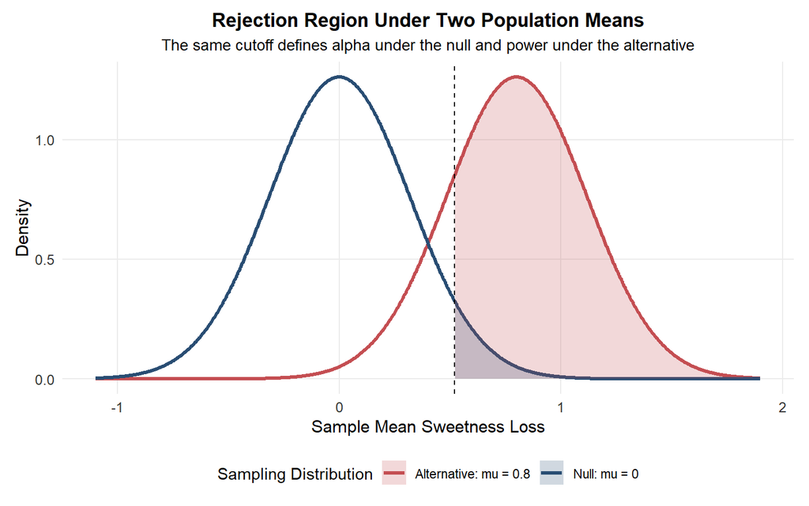

In the graph, the area to the right of the cutoff under the null distribution is $\alpha=0.05$. The area to the right of the same cutoff under the alternative distribution is the power.

The calculation can be checked in R.

```r
sigma <- 1
n <- 10
alpha <- 0.05
mu_0 <- 0
mu_alternative <- 0.8

standard_error <- sigma / sqrt(n)
critical_x_bar <- qnorm(
  1 - alpha,
  mean = mu_0,
  sd = standard_error
)

power <- pnorm(
  critical_x_bar,
  mean = mu_alternative,
  sd = standard_error,
  lower.tail = FALSE
)

c(
  critical_sample_mean = critical_x_bar,
  power = power
)
```

```
## critical_sample_mean                power
##            0.5201484            0.8119132
```

### 15.6.10 Example 15.7 (continued): Type I and Type II Error Probabilities

The sweetness test uses

$$\alpha=0.05$$

Therefore,

$$P(\text{Type I error})
=
P(\text{reject }H_0\mid\mu=0)
=
0.05$$

The test has power $0.812$ against $\mu=0.8$. Therefore,

$$P(\text{Type II error at }\mu=0.8)
=
\beta$$

$$\beta
=
1-0.812
=
0.188$$

In context:

- A Type I error means concluding that storage causes a population mean sweetness loss when the true mean loss is $0$
- A Type II error at $\mu=0.8$ means failing to detect a mean loss of $0.8$ point when that loss is real

The value of $\beta$ changes when the specified alternative changes.

### 15.6.11 Factors That Affect Power and Required Sample Size

The following changes generally require a larger sample:

- Reducing $\alpha$, because stronger evidence is required to reject $H_0$
- Increasing the target power, because the study must detect the effect more reliably
- Using a two-sided alternative instead of a one-sided alternative
- Planning to detect a smaller effect
- Studying a population with greater variability

The following relationships are useful:

| Planning change | Effect on required sample size |
| --- | --- |
| Smaller $\alpha$ | Increases required $n$ |
| Higher target power | Increases required $n$ |
| Smaller effect to detect | Increases required $n$ |
| Larger $\sigma$ | Increases required $n$ |
| Two-sided rather than one-sided test | Usually increases required $n$ |

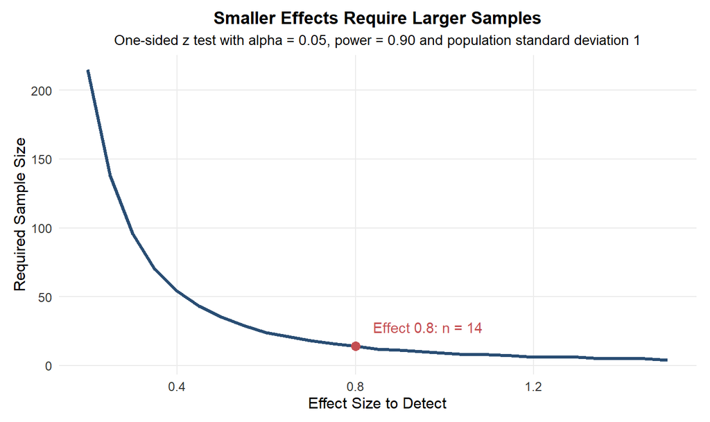

The curve illustrates the trade-off between the effect size a study is designed to detect and the required sample size. Detecting a smaller meaningful effect with the same significance level, power and population variability requires a larger sample. For the sweetness-study planning values, an effect of $0.8$ point requires $14$ tasters after rounding up.

For the one-sided sweetness test, a Normal-theory planning formula gives

$$n
=
\left(
\frac{(z_{1-\alpha}+z_{\text{power}})\sigma}{\delta}
\right)^2$$

where $\delta$ is the effect size to be detected.

Using

$$\alpha=0.05
\qquad
\text{power}=0.90
\qquad
\sigma=1
\qquad
\delta=0.8$$

gives

$$n
=
\left(
\frac{(1.645+1.282)(1)}{0.8}
\right)^2
\approx
13.38$$

Therefore, at least

$$\boxed{n=14}$$

tasters are required under this planning model.

```r
alpha <- 0.05
target_power <- 0.90
sigma <- 1
effect_size <- 0.8

z_alpha <- qnorm(1 - alpha)
z_power <- qnorm(target_power)

unrounded_n <- (
  (z_alpha + z_power) * sigma / effect_size
)^2

ceiling(unrounded_n)
```

```
## [1] 14
```

## 15.7 Chapter Summary

Reliable statistical inference requires the procedure, study design and scientific question to fit one another.

### 15.7.1 Probability Foundations

- Probability models describe the outcomes that could occur under stated assumptions
- Sampling distributions connect those models to statistics such as $\bar{x}$, $\hat p$ and event counts
- Complements, disjoint-event addition, conditional probability and independence appear directly in inferential calculations
- The response and study design determine whether a Normal, binomial, Poisson or another probability model is appropriate
- Exact calculations retain the original discrete model; Normal approximations require adequate conditions
- A P-value has the form $P(\text{data at least as extreme as observed}\mid H_0)$, not $P(H_0\mid\text{data})$

### 15.7.2 Conditions for Inference

- Random sampling supports population generalization
- Random assignment supports causal treatment comparisons
- Nonresponse, attrition and measurement problems can weaken an otherwise sound design
- Complex sampling designs require methods that account for their structure
- Graphs, sample size and subject-matter knowledge help assess distributional conditions
- Outliers can strongly affect inference based on the sample mean

### 15.7.3 Confidence Intervals

For a one-sample $z$ interval,

$$\bar{x}
\pm
z^*\frac{\sigma}{\sqrt{n}}$$

and

$$m
=
z^*\frac{\sigma}{\sqrt{n}}$$

Higher confidence and greater variability increase the margin of error. Larger samples decrease it according to the square-root relationship.

The margin of error measures random sampling variation under the model. It does not measure bias from poor sampling, nonresponse, confounding or systematic measurement error.

### 15.7.4 Hypothesis Tests

For a one-sample $z$ test,

$$z
=
\frac{\bar{x}-\mu_0}{\sigma/\sqrt{n}}$$

Statistical significance depends on the observed effect, population variability and sample size.

A small P-value provides evidence against the null model. It does not give the probability that $H_0$ is true, measure the effect size or determine practical importance.

Multiple analyses and selective reporting can increase false-positive findings. Transparent planning and independent replication strengthen scientific evidence.

### 15.7.5 Study Planning

For a desired confidence-interval margin of error,

$$n
=
\left(
\frac{z^*\sigma}{m}
\right)^2$$

The result is rounded up.

Planning a hypothesis test requires a significance level, a meaningful effect size and a target power.

$$\text{Power}
=
1-\beta$$

Larger samples increase precision and usually increase power. Statistical planning should occur before data collection so that the study has a reasonable chance of answering its scientific question.

### 15.7.6 A Consistent Workflow

1. Define the population, parameter and scientific question.
2. Examine how the data were collected.
3. Assess independence, distributional conditions and unusual observations.
4. Select a probability model and inferential procedure that match the response and design.
5. Report the estimate, confidence interval and exact P-value when appropriate.
6. Distinguish statistical evidence from practical importance.
7. Describe limitations and the scope of the conclusion.
8. Replicate important findings when possible.